# Temperature and Autothefts

```r
# November 09th 2019
#
# To do on November 31st 2019
#
# THINGS TO DO:
#
# Check vars names in section
#
# Weird graph block for low crime data sumamry
#
# histogram titles
#
# remove junk slides (clean up)
#
# conciseness and grammar
#
# print slides
#
# write and rehearse script
#
#
# Practice presenting in 5 minutes
#
# need to do more classification
# either classification or regression and try to predict something
#
# Add creative aspect in script of project
#
# Define crime rate so we can use it in our graph axes/titles
```

````r
# ```{r, echo=FALSE, message=FALSE, warning=FALSE}
# # echo=FALSE will stop the code chunk from appearing in the knit document
# # warning=FALSE and message=FALSE will stop R messages from appearing in the knit document
# #loading proper libraries
# library(tidyverse)
# library(knitr)
# # loading neighbourhood data
# neighbourhood <- read.csv(file="2016neigh.csv") %>% select(Hood_ID, pop_2016)
# #loading autothefts data and joining with neighbourhood data
# thefts <- read.csv(file="auto_thefts.csv") %>% select(occurrencedate, Neighbourhood, Hood_ID) %>% full_join(y=neighbourhood, key="Hood_ID")
# #loading weather data from 5 years
# T14 <- read.csv(file="2014 Toronto.csv") %>% select(Date.Time,Mean.Temp.C)
# T15 <- read.csv(file="2015 Toronto.csv") %>% select(Date.Time,Mean.Temp.C)
# T16 <- read.csv(file="2016 Toronto.csv") %>% select(Date.Time,Mean.Temp.C)
# T17 <- read.csv(file="2017 Toronto.csv") %>% select(Date.Time,Mean.Temp.C)
# T18 <- read.csv(file="2018 Toronto.csv") %>% select(Date.Time,Mean.Temp.C)
# #joining weather data into one data frame and removing NA values
# temperature <- rbind(T14, T15, T16, T17, T18)
# #joining weather data (temperature) with thefts by date
# ```
# Data wrangling starts here!
# ```{r}
# date <- rep(NA, 18178)
# for (i in 1:18178){
#   date[i] <- substring(thefts$occurrencedate[i],1,10)
# }
# ```
#
#
# ```{r}
# #cleaing up thefts data more
# thefts <- thefts %>% mutate(date=date) %>% rename(Date.Time=date) %>% select(Neighbourhood, Hood_ID,pop_2016,Date.Time)
# ```
#
#
# ```{r}
# #joining thefts to temperature that day
# autothefts <- inner_join(x=thefts,y=temperature, key="Date.Time") %>% filter(!is.na(Mean.Temp.C))
# ```
#
#
# ```{r}
# #add a new variable to classify by high/low crime rate neighbourhood (rate per 1000)
# crimerate <- autothefts %>% group_by(Hood_ID) %>% summarise(rate=1000*n()/mean(pop_2016))
# autothefts <- full_join(x=autothefts,y=crimerate,key="Hood_ID")
# autothefts <- autothefts %>% mutate(crimerate=ifelse(rate>=median(rate),"High","Low"))
# ```
#
# ```{r}
# #add a new variable to classify by hot and cold dats
# autothefts <- autothefts %>% mutate(hot_cold=ifelse(Mean.Temp.C>=median(Mean.Temp.C), "Hot", "Cold"))
# ```
#
````

Data wrangling starts here!

```r
date <- rep(NA, 18178)
for (i in 1:18178){
  date[i] <- substring(thefts$occurrencedate[i],1,10)
}
```

```r
#cleaing up thefts data more
thefts <- thefts %>% mutate(date=date) %>% rename(Date.Time=date) %>% select(Neighbourhood, Hood_ID,pop_2016,Date.Time)
```

```r
#joining thefts to temperature that day
autothefts <- inner_join(x=thefts,y=temperature, key="Date.Time") %>% filter(!is.na(Mean.Temp.C))
#add a new variable to classify by high/low crime rate neighbourhood (rate per 1000)
crimerate <- autothefts %>% group_by(Hood_ID) %>% summarise(rate=1000*n()/mean(pop_2016))
autothefts <- full_join(x=autothefts,y=crimerate,key="Hood_ID")
autothefts <- autothefts %>% mutate(crimerate=ifelse(rate>=quantile(rate,0.75),"High",ifelse(rate<=quantile(rate,0.25),"Low","Medium")))
```

```r
#add a new variable to classify by hot and cold days by median
autothefts <- autothefts %>% mutate(hot_cold=ifelse(Mean.Temp.C>=quantile(Mean.Temp.C,0.75), "Hot", ifelse(Mean.Temp.C<=quantile(Mean.Temp.C,0.25),"Cold","Medium")))
```

```r
# #Code For Graphs Below
#
#
# #histogram of crime rate distribution
# histogram_of_crime_rate_distribution <- ggplot(data=autothefts) + aes(x=rate) + geom_histogram(bins=100, color="black", fill="blue")
# #right skewed data so we use median
#
# #histogram of temperature distributions
# histogram_of_temperature_distributions <- ggplot(data=autothefts) + aes(x=Mean.Temp.C) + geom_histogram(bins=50, color="black", fill="red")
# #left skew so we use median again
#
#
#
# #For Data Summary Slides
# #Crime_Rate_Over_Temperature <- ggplot(data = autothefts) +
# #  aes(x = Mean.Temp.C, y = Rate) + geom_polygon() + facet_wrap(~crimerate)
# #Crime_Rate_Over_Temperature
# Crime_Rate_Over_Temperature <- ggplot(data = autothefts) +
#   aes(x = Mean.Temp.C, y = rate) + geom_smooth() + facet_wrap(~crimerate)
# Crime_Rate_Over_Temperature
#

Low_Crime <- autothefts %>% filter(crimerate == 'Low')
Low_Crime_Graph <- ggplot(data = Low_Crime) +
  aes(x = Mean.Temp.C, y = rate) + geom_smooth() + xlab('Mean Daily Temperature in °C') + ylab('Auto Thefts per Thousand Persons') + ggtitle('Temperature V.S. Thefts in Low Crime Neighbourhood')
#Low_Crime_Graph

High_Crime <- autothefts %>% filter(crimerate == 'High')
High_Crime_Graph <- ggplot(data = High_Crime) +
  aes(x = Mean.Temp.C, y = rate) + geom_smooth() + xlab('Mean Daily Temperature in °C') + ylab('Auto Thefts per Thousand Persons') + ggtitle('Temperature V.S. Thefts in High Crime Neighbourhood')
#High_Crime_Graph



#quartile data
quantiletempsummary <- quantile(autothefts$Mean.Temp.C,c(0.25,0.5,0.75))
quantilecrimesummary <- quantile(autothefts$rate,c(0.25,0.5,0.75))
```

```r
#State H0: there is no difference, we sim under this assumption
#State HA: there is a difference (significant)

#calculate test statistic as difference in crime rate on hot and cold days
High_Crime_meanrates_by_temp <- High_Crime %>% filter(hot_cold!="Medium") %>% group_by(hot_cold) %>% summarise(means=mean(rate))
High_Crime_test_stat <- diff(High_Crime_meanrates_by_temp$means) %>% as.numeric()
#simulate the difference in crime rate(per 1000) on hot vs cold days by shuffling labels
reps1 <- 5000
sim_diff <- rep(NA,reps1)
set.seed(130)
for (i in 1:reps1){
  sim <- High_Crime %>% filter(hot_cold!="Medium") %>% mutate(hot_cold=sample(hot_cold)) %>% group_by(hot_cold) %>% summarise(means=mean(rate)) %>% summarise(diff(means)) %>% as.numeric()
  sim_diff[i] <- sim
}
```

```r
HighCrimeResults <- ggplot(data_frame(diff_mean_rates=sim_diff)) + aes(x=diff_mean_rates) + geom_histogram(bins=30, color="black", fill="grey") + geom_vline(xintercept=High_Crime_test_stat, color="red") + geom_vline(xintercept=-High_Crime_test_stat, color="red") + xlab('Difference in Crime Rate Between Hot and Cold Days') + ylab('Count') + ggtitle('Distribution of Difference in Crime Rate in High Crime Neighbourhoods')
#Graph distribution and show p value
```

```r
#do the same thing as above for low risk neighbourhoods
#State H0: there is no difference
#State HA: there is a difference (significant)

#calculate test statistic as difference in crime rate on hot and cold days
Low_Crime_meanrates_by_temp <- Low_Crime %>% filter(hot_cold!="Medium") %>% group_by(hot_cold) %>% summarise(means=mean(rate))
Low_Crime_test_stat <- diff(Low_Crime_meanrates_by_temp$means) %>% as.numeric()
#simulate the difference in crime rate(per 1000) on hot vs cold days by shuffling labels
sim_diff2 <- rep(NA,reps1)
set.seed(130)
for (i in 1:reps1){
  sim <- Low_Crime %>% filter(hot_cold!="Medium") %>% mutate(hot_cold=sample(hot_cold)) %>% group_by(hot_cold) %>% summarise(means=mean(rate)) %>% summarise(diff(means)) %>% as.numeric()
  sim_diff2[i] <- sim
}
```

```r
LowCrimeResults <- ggplot(data_frame(diff_mean_rates=sim_diff2)) + aes(x=diff_mean_rates) + geom_histogram(bins=30, color="black", fill="grey") + geom_vline(xintercept=Low_Crime_test_stat, color="red") + geom_vline(xintercept=-Low_Crime_test_stat, color="red") + xlab('Difference in Crime Rate Between Hot and Cold Days') + ylab('Count') + ggtitle('Distribution of Difference Crime Rate Between Hot and Cold Days in Low Crime Neighbourhoods')
#Graph distribution and show p value
```

```r
#calculate p value
High_Crime_pvalue <- data_frame(diff_mean_rates=sim_diff) %>%
  filter(diff_mean_rates<=-abs(High_Crime_test_stat)|diff_mean_rates>=abs(High_Crime_test_stat)) %>%
summarise(pvalue=n()/reps1)
#make a conclusion
```

```r
#calculate p value
Low_Crime_pvalue <- data_frame(diff_mean_rates=sim_diff2) %>%
  filter(diff_mean_rates<=-abs(Low_Crime_test_stat)|diff_mean_rates>=abs(Low_Crime_test_stat)) %>%
summarise(pvalue=n()/reps1)
#make a conclusion
```

```r
#trend with error
#name axis
trend_crimerate_and_temp <- ggplot(data=autothefts) + aes(x=Mean.Temp.C, y=rate) + geom_smooth()
#+ scale_y_discrete(breaks = c(0,10,20,30,40,50), labels=c("0","10","20","30","40","50"), limits=c(0,50))#we have to explain this
```

## Introduction

Does relativley extreme temperature affect auto thefts rates?

- Using autothefts data from the Toronto Police Department
- Using historical weather from the government of Canada in the city of Toronto between years 2014 to 2018
  - Averaging the daily temperature
  - Using the 3rd and 1st quartile of mean temperature/day, we seperated the days in hot and cold categories respectivly
  - Using the 3rd and 1st quartile of crime/neighbourhood, we seperated the neighbourhoods in High and Low categories respectivly
- High/Low and Hot/Cold so as to check the extreme conditions -Data was collected over 5 years of reports

## Objectives

- Does relativley extreme temperature affect auto thefts rates?
- To visualise and estimate the effect, if there are any, of ‘hot’ and ‘cold’ days in ‘high’ and ‘low’ crime neighbourhoods in relation with autothefts.

## Data Summary

- We joined Toronto Police Department Neighbourhood data with the Car Auto Theft Data
- We added variables to the Weather data:
  - Mean Temp C
    - The average temperature for every day in the year that had car theft data
  - Rate
    - Number of auto thefts per thousand persons
- Crimerate
  - Neighbourhoods seperated into ‘Low’ and ‘High’ categories (below 25% and above 75%)

```r
quantilecrimesummary
```

```
##       25%       50%       75%
##  4.681427  7.477943 11.595435
```

- Hot_Cold
  - Every day in the year seperated into ‘Hot’ and ‘Cold’ categories (below 25% and above 75%)

```r
quantiletempsummary
```

```
##  25%  50%  75%
##  2.2 10.5 19.3
```

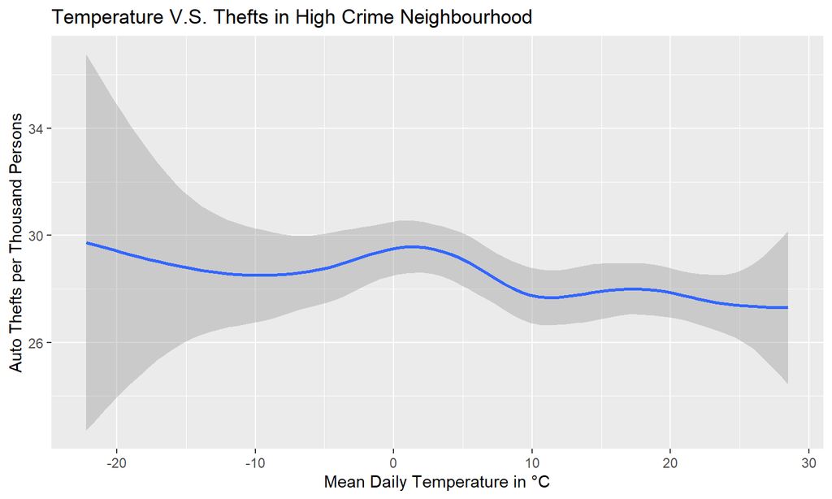

```r
High_Crime_Graph
```

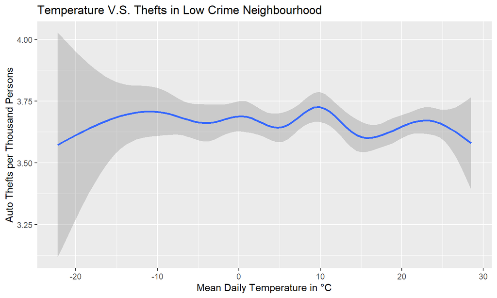

```r
Low_Crime_Graph
```

## Statistical Methods

To verify our objective, we seperated our question in 2 Null Hypotheses

Null Hypothesis 1: Among high risk neighbourhoods there ire no difference in the auto theft rate on very hot days and very cold days

Null Hypothesis 2: Among low risk neighbourhoods there ire no difference in the auto theft rate on very hot days and very cold days

We operated under the assumption that the Null Hypotheses were true

-meaning that there should be no difference between crime rates between hot and cold days

Therefore to check the null hypotheses, we simulated values of the test statistic by shuffling the hot and cold labels and compared the probability of getting a result at least as extreme as our test statistic.

-If they are at least as extreme as our test statistic, then our Null Hypotheses are true, if not, then we would have no strong evidence to support it.

## Results

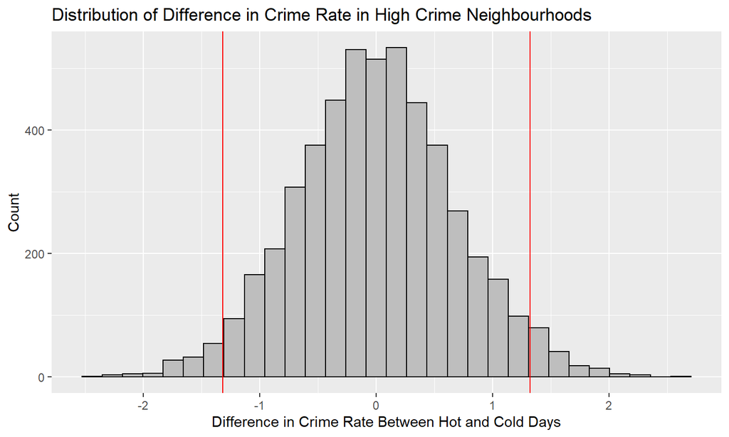

```r
HighCrimeResults
```

```r
High_Crime_pvalue
```

```
## # A tibble: 1 x 1
##   pvalue
##    <dbl>
## 1  0.056
```

Our test statistic was -1.30, meaning there were 1.3 more auto thefts per 5 years per thousand people on cold days compared to really hot days.

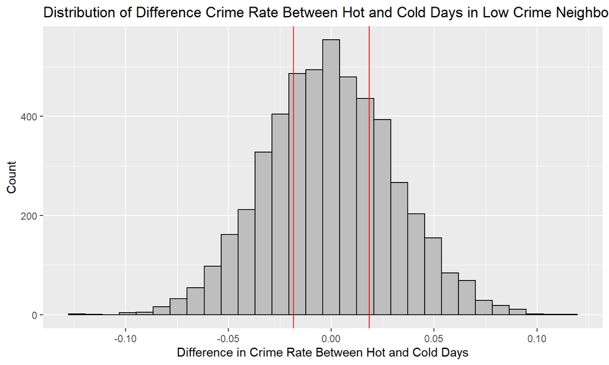

```r
LowCrimeResults
```

```r
Low_Crime_pvalue
```

```
## # A tibble: 1 x 1
##   pvalue
##    <dbl>
## 1  0.556
```

Our test statistic was -0.02, meaning there were 0.02 more auto thefts per 5 years per thousand people on cold days compared to really hot days.

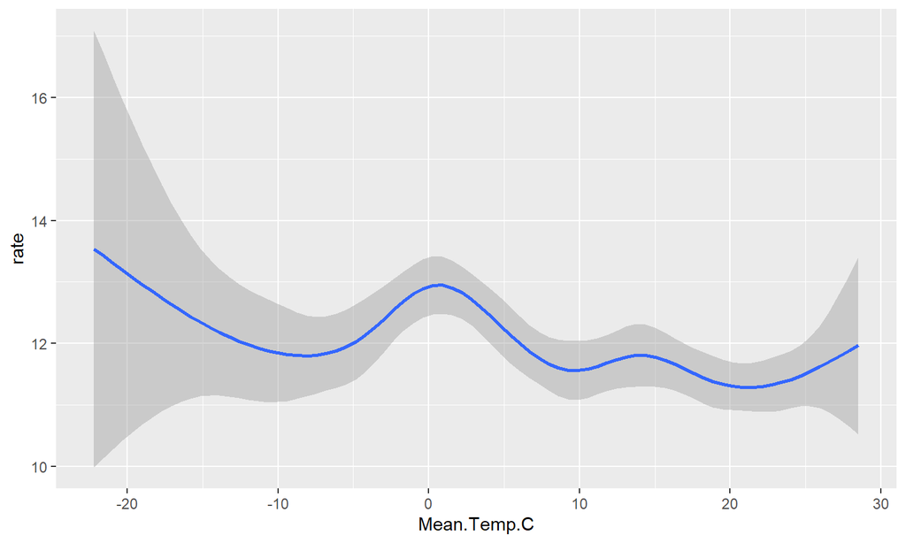

```r
trend_crimerate_and_temp
```

There is moderate evidence that there is a difference in the crime rate on hot and cold days in high risk neighboorhoods but there is no evidence that there is any such difference in low risk neighbourhoods.

## Limitations

- Type 1 Error for High Risk
  - It possible that the moderate evidence that we see is an error and that there is actually no difference, in this case we are leaning towards a type 1 error by concluding there is evidence agaisn’t the null.
- Type 2 Error for Low Risk
  - It is unlinkley that the null hypothesis is actually false –taking into context the high P value.
- Auto thefts rate per population might not be the best measure, an example would be that
  - One of the High risk neighbourhoods was a low population industrial district, one could assume that in this case this neighbourhood had a higher proportion of unnatended cars during the day.

## Conclusions

The purpose of this statistical invsetigation was to determine if relatively extreme weather conditions in Toronto, Ontario, Canada, would have an effect on the rate of reported car thefts. Based on our results, we conclude that in neighbourhoods with a historical higher rate of auto thefts, colder weather is more likely to be correlated with car thefts. In neighbourhoods without that historical distinction, there is no evidence to suggest the same.

## Extensions

After this long statistical and (hopefully) coherent ramble, one may ask: what should the police do in a situation like this? We simply suggest to keep an eye out on high car theft risk neighbourhoods, especially in cold weather, rather than overcommit resources to lower risk neighbourhoods which do not run such a risk.

## Acknowledgements (optional)

*The authors would like to thank “Kevin” for helpful suggestions and comments that improved the presentation of this poster.*

## A Section Heading on its own page

## A heading that starts on a new page

This document shows a few basics on making slides with R markdown.

To produce the slides, Knit to HMTL (ioslides).

(You can also knit to PDF if you have LaTeX installed on your computer.)

Three dashes starts a new page when it is not started by a new header.

### This is a heading that doesn’t start a new page

You can make text **bold** or in *italics*.

To make bullet points, start the points after a blank line:

- point one
- another point

Include some R output

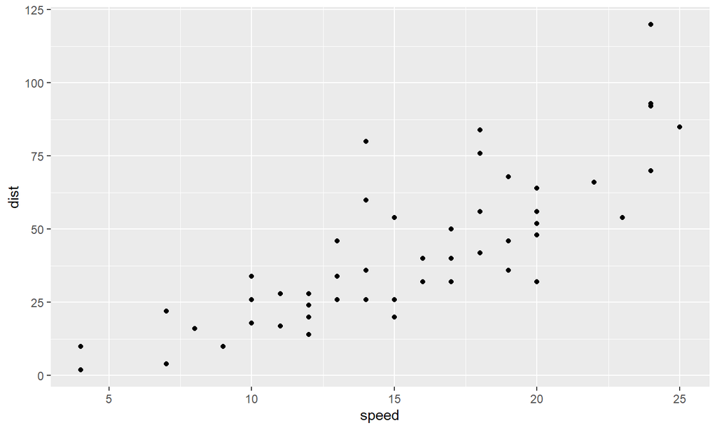

```r
ggplot(cars, aes(x=speed, y=dist)) + geom_point()
```

Include the output without showing the code and R messages (which is what you want for your poster presentation). This R code chunk also changes the size of the plot.

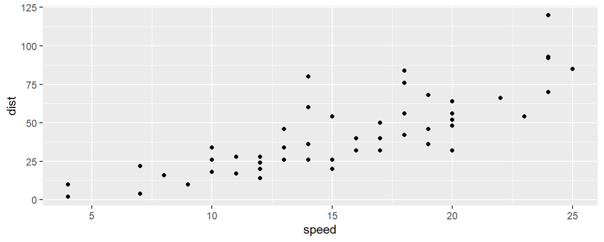

This plot shows that there is a positive relationship between distance and speed.

## Read more

There is more information on R markdown on the course website at https://ntaback.github.io/UofT_STA130/Rmarkdownforclassreports.html

For more on creating an `ioslides` presentation see https://rmarkdown.rstudio.com/ioslides_presentation_format.html

## Headings you should include in your project

## Introduction

Include here a few sentences to introduce the problem and provide context. You might want to briefly summarize the data in words (what is the data and what is it used for). You can present the questions you are investigating here.

## Objectives (optional)

You can list the questions of interest in complete English sentences here to highlight them.

## Data Summary (optional)

Here you can explain how you cleaned the data and created variables suitable for answering your questions. You can also include graphical displays that either motivated or address the questions.

## Statistical Methods

Describe here what you have done to the data without presenting any results (output). If you want to indicate variables by symbols or variable names, define them here.

## Results

Present the main results here, in order of importance, related to the questions asked. You might use tables or graphs, or other ways to summarize your results.

## Conclusion

Give your main conclusions here. Follow the order of questions you presented.

Here you can also mention any additional considerations, concerns, or issues you might have. For example, if the results were unexpected, you can discuss this and perhaps offer possible explanations.

## Acknowledgements (optional)

If you received any help from someone other than your team members you can acknowledge them. For example:  
*The authors would like to thank “TA name” for helpful suggestions and comments that improved the presentation of this poster.*